# Exploratory Data Analysis

### Figure 2

Then the number of jobs(frequencies) of the softwares in other category have explorated by a **“wordcloud”**.

```r
sw3<-filter(counts,no_rows<80)
sw3
```

```
# A tibble: 30 x 2
   RequiredSoftwares  no_rows
   <chr>                <int>
 1 Alteryx                  3
 2 Bash                     1
 3 C#                       2
 4 C++                     16
 5 cloud_storage           65
 6 Computer_vision         20
 7 Content_Management       1
 8 Data_warehouse          39
 9 DigitalOcean             3
10 Hive                    28
# ... with 20 more rows
```

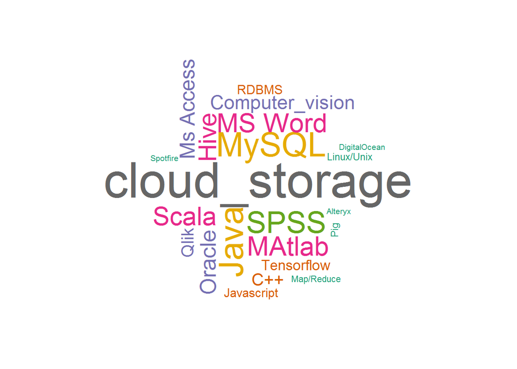

```r
set.seed(100)
wordcloud(words = sw3$RequiredSoftwares,freq = sw3$no_rows,random.order = FALSE,rot.per = 0.35,colors = brewer.pal(10,"Dark2"))
```

### **Job Titles**

There are many types of job titles it is harder to plot all job titles. Therefore it has been categorized jobs into three main categories, and other job titles keep as other.

```r
Job_Titles<-str_to_lower(MyDataSet$Job_title)
Job_Titles<-str_replace_all(Job_Titles,","," ")
Job_Titles%>%head()
```

```
[1] NA
[2] "junior data scientist"
[3] "engineer  analytics and data science"
[4] "ci-statistical analyst/business analyst-cmb"
[5] "da-data analyst-cmb"
[6] "data scientist"
```

```r
DS<-Job_Titles[str_detect(Job_Titles,"([data]{4}\\s*[scientist]{7,9})")] %>% unique()
DE<-Job_Titles[str_detect(Job_Titles,"([data]{4}\\s*[engineer]{8})")]%>%unique()
DA<-Job_Titles[str_detect(Job_Titles,"([data]{4}\\s*[analyst]{7}|[analytics]{8,9})")]%>%unique()
Others<-Job_Titles[!(Job_Titles%in%c(DS,DE,DA))]
#MyDataSet
```

Then the Job titles are categorized into 3 main categories such as DS(Data Scientist), DE(Data Engineer) and DA(Data Analyst) and remaining titles are kept as other.

```r
Tbl<-data.frame(Job_Title=c("DS","DE","DA","Others"),Count=c(sum(Job_Titles%in%DS),sum(Job_Titles%in%DE),sum(Job_Titles%in%DA),sum(Job_Titles%in%Others)))
Tbl
```

```
  Job_Title Count
1        DS   214
2        DE    22
3        DA   156
4    Others    56
```

### Figure 3

```r
barsoft2<-tibble(Job_Title=c("DS","DE","DA","Others"),No_jobs=c(213,21,155,56))
barsoft2
```

```
# A tibble: 4 x 2
  Job_Title No_jobs
  <chr>       <dbl>
1 DS            213
2 DE             21
3 DA            155
4 Others         56
```

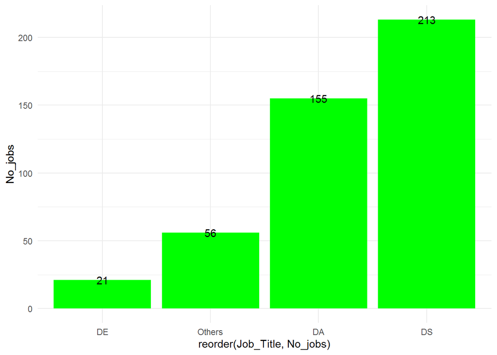

```r
ggplot(data =barsoft2,aes(x=reorder(Job_Title,No_jobs),y=No_jobs))+geom_bar(stat = "identity",fill="green")+geom_text(aes(label=No_jobs))+theme_minimal()
```

**Interpretation**

According to the Figure 3 most of jobs titles are in Data Scientist Category and least number of jobs are in category Data engineering category.

```r
MyDataSet1<-pivot_longer(MyDataSet,c(21:24,27:30,34,41:52,54,55,59:61,64,67:69,75:93,100:105),"KnowledgeAndSkills","Status")
MyDataSet2<-filter(MyDataSet1,value=="1")
#MyDataSet2
```

```r
unique(MyDataSet2$KnowledgeAndSkills)
```

```
 [1] "Data_visualization"               "BigData"
 [3] "Machine_Learning"                 "Natural_Language_Processing(NLP)"
 [5] "Microsoft Power BI"               "C"
 [7] "Spark"                            "S3"
 [9] "Redshift"                         "Data_mining"
[11] "PHP"                              "Flash_Actionscript"
[13] "web_design_and_development_tools" "graphics_and_design_skills"
[15] "Data_science"                     "Tableau"
[17] "D3"                               "Hadoop"
[19] "agile execution"                  "Google_Analytics"
[21] "Google_Cloud"                     "AWS"
[23] "Communication"                    "Optimization"
[25] "Deep Learning"                    "Bayesian"
[27] "AI"                               "Presentation_Skills"
[29] "Impala"                           "Solr"
[31] "Problem_Solving"                  "Korean_language"
[33] "Economic"                         "Numerical_Analysis"
[35] "Finance_Knowledge"                "Investment_Knowledge"
[37] "Web_Analytic_tools"               "Team_Handling"
[39] "Debtor_reconcilation"             "Payroll_management"
[41] "YOLO"                             "IOT"
[43] "Kafka"                            "Data_Pipelines"
[45] "MPP_Platforms"                    "MongoDB"
[47] "Elasticsearch"                    "Data_marketing"
[49] "SEO"                              "Data_management"
[51] "pyspark"                          "Teradata"
[53] "SPL"
```

```r
attach(MyDataSet2)
counts2<-MyDataSet2%>%group_by(KnowledgeAndSkills)%>%summarise(no_rows2=length(KnowledgeAndSkills))
counts2
```

```
# A tibble: 53 x 2
   KnowledgeAndSkills no_rows2
   <chr>                 <int>
 1 agile execution           9
 2 AI                       52
 3 AWS                      18
 4 Bayesian                  3
 5 BigData                 126
 6 C                         6
 7 Communication           216
 8 D3                        8
 9 Data_management           2
10 Data_marketing            3
# ... with 43 more rows
```

```r
arrange(counts2,desc(counts2$no_rows2))
```

```
# A tibble: 53 x 2
   KnowledgeAndSkills  no_rows2
   <chr>                  <int>
 1 Communication            216
 2 Machine_Learning         195
 3 Data_visualization       170
 4 BigData                  126
 5 Team_Handling            110
 6 Data_science             105
 7 Problem_Solving           89
 8 Presentation_Skills       77
 9 Tableau                   73
10 Data_mining               54
# ... with 43 more rows
```